# AN597_Boots_cmgagnon

Christian Gagnon

11/11/2019

#Bootstrapping Standard Errors and CIs for Linear Models.

When we initially discussed the central limit theorem and confidence intervals, we showed how we could use bootstrapping to estimate standard errors and confidence intervals around certain parameter values, like the mean. Using bootstrapping, we could also do the same for estimating standard errors and CIs around regression parameters, such as β coefficients.

##[1] Using the “KamilarAndCooperData.csv” dataset, run a linear regression looking at log(HomeRange_km2) in relation to log(Body_mass_female_mean) and report your β coeffiecients (slope and intercept).

```r
library(curl)
library(dplyr)
library(car)
```

```r
library(ggplot2)
f <- curl("https://raw.githubusercontent.com/fuzzyatelin/fuzzyatelin.github.io/master/AN597_Fall19/KamilarAndCooperData.csv")
d <- read.csv(f, header = TRUE, sep = ",", stringsAsFactors = TRUE)
head(d)
```

```
##               Scientific_Name          Family          Genus      Species
## 1 Allenopithecus_nigroviridis Cercopithecidae Allenopithecus nigroviridis
## 2         Allocebus_trichotis Cercopithecidae      Allocebus    trichotis
## 3           Alouatta_belzebul        Atelidae       Alouatta     belzebul
## 4             Alouatta_caraya        Atelidae       Alouatta       caraya
## 5            Alouatta_guariba        Atelidae       Alouatta      guariba
## 6           Alouatta_palliata        Atelidae       Alouatta     palliata
##   Brain_Size_Species_Mean Brain_Size_Female_Mean   Brain_size_Ref
## 1                   58.02                  53.70 Isler et al 2008
## 2                      NA                     NA
## 3                   52.84                  51.19 Isler et al 2008
## 4                   52.63                  47.80 Isler et al 2008
## 5                   51.70                  49.08 Isler et al 2008
## 6                   49.88                  48.04 Isler et al 2008
##   Body_mass_male_mean Body_mass_female_mean Mass_Dimorphism
```

[output cut: 69 more lines]

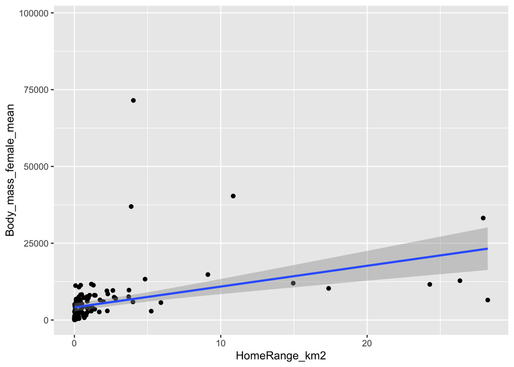

```r
g <- ggplot(data = d, aes(x = HomeRange_km2, y = Body_mass_female_mean))
g <- g + geom_point()
g <- g + geom_smooth(method = "lm", formula = y ~ x)
g
```

This visualization is ok but I think I will try logging both variables.

I found a different method, lets give this a try:

```r
library(ggpmisc)
m <- lm(data = d, HomeRange_km2 ~ Body_mass_female_mean)
summary(m)
```

```
##
## Call:
## lm(formula = HomeRange_km2 ~ Body_mass_female_mean, data = d)
##
## Residuals:
##      Min       1Q   Median       3Q      Max
## -14.0240  -1.5045  -0.6688  -0.4262  26.1404
##
## Coefficients:
##                        Estimate Std. Error t value Pr(>|t|)
## (Intercept)           5.041e-01  4.651e-01   1.084     0.28
## Body_mass_female_mean 2.454e-04  4.736e-05   5.183 7.78e-07 ***
## ---
## Signif. codes:  0 '***' 0.001 '**' 0.01 '*' 0.05 '.' 0.1 ' ' 1
##
## Residual standard error: 4.56 on 135 degrees of freedom
##   (76 observations deleted due to missingness)
## Multiple R-squared:  0.166,  Adjusted R-squared:  0.1598
## F-statistic: 26.87 on 1 and 135 DF,  p-value: 7.777e-07
```

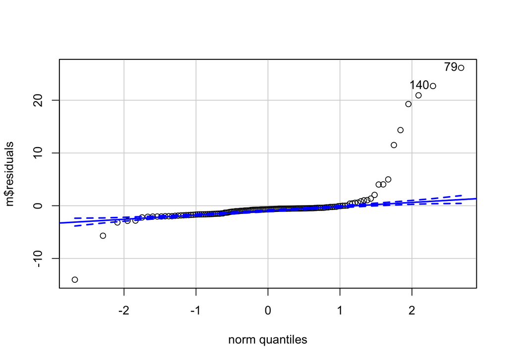

```
##  79 140
##  46  87
```

```r
qqPlot(m$residuals)
```

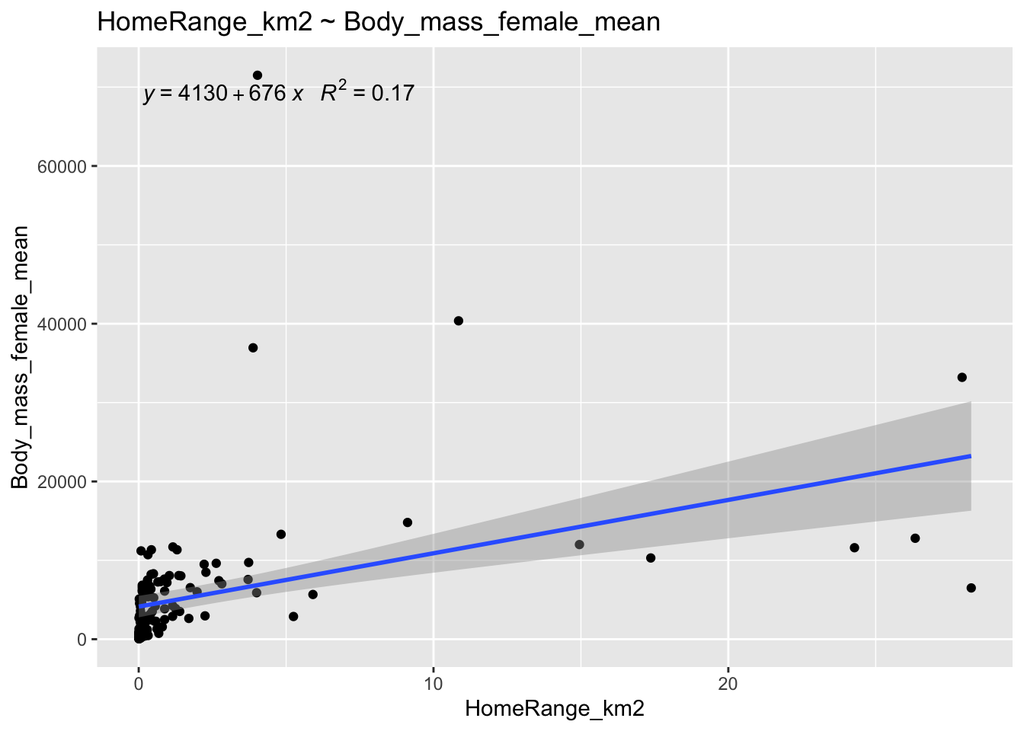

```r
ggplot(data = m, aes(x = HomeRange_km2, y = Body_mass_female_mean)) + ggtitle("HomeRange_km2 ~ Body_mass_female_mean") + geom_point() + geom_smooth(method = "lm",
    formula = y ~ x) + stat_poly_eq(formula = y ~ x, aes(label = paste(..eq.label.., ..rr.label.., sep = "~~~")),
    parse=TRUE,label.x.npc = "left")
```

Coefficients: Estimate Std. Error (Intercept) 5.041e-01 4.651e-01 Body_mass_female_mean 2.454e-04 4.736e-05 t value Pr(>|t|)  
(Intercept) 1.084 0.28  
Body_mass_female_mean 5.183 7.78e-07 ***

Now with log:

```r
mlog <- lm(data = d, log(HomeRange_km2) ~ log(Body_mass_female_mean))
summary(mlog)
```

```
##
## Call:
## lm(formula = log(HomeRange_km2) ~ log(Body_mass_female_mean),
##     data = d)
##
## Residuals:
##     Min      1Q  Median      3Q     Max
## -3.3929 -0.9433 -0.0126  1.0944  3.6826
##
## Coefficients:
##                            Estimate Std. Error t value Pr(>|t|)
## (Intercept)                -9.44123    0.67293  -14.03   <2e-16 ***
## log(Body_mass_female_mean)  1.03643    0.08488   12.21   <2e-16 ***
## ---
## Signif. codes:  0 '***' 0.001 '**' 0.01 '*' 0.05 '.' 0.1 ' ' 1
##
## Residual standard error: 1.423 on 135 degrees of freedom
##   (76 observations deleted due to missingness)
## Multiple R-squared:  0.5248, Adjusted R-squared:  0.5213
## F-statistic: 149.1 on 1 and 135 DF,  p-value: < 2.2e-16
```

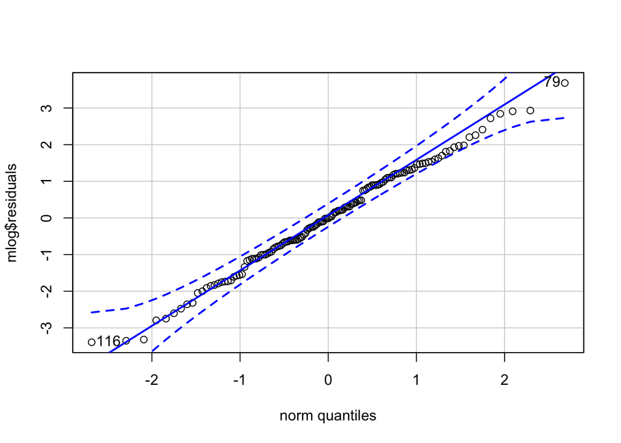

```
##  79 116
##  46  74
```

```r
qqPlot(mlog$residuals)
```

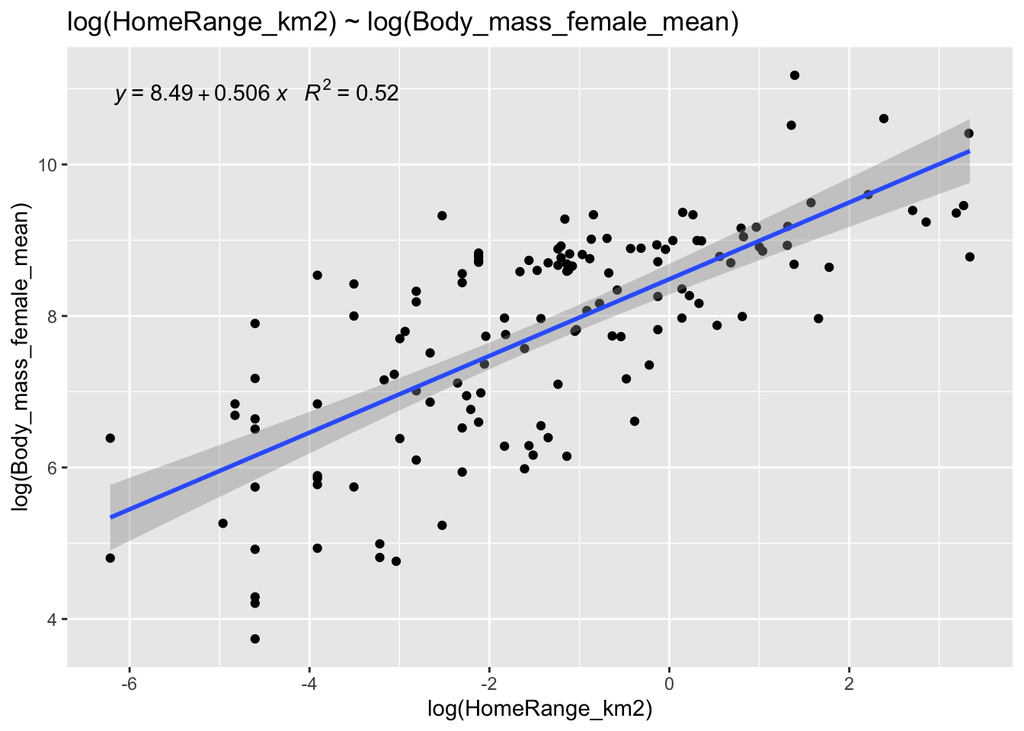

```r
ggplot(data = m, aes(x = log(HomeRange_km2), y = log(Body_mass_female_mean))) + ggtitle("log(HomeRange_km2) ~ log(Body_mass_female_mean)") + geom_point() + geom_smooth(method = "lm",
    formula = y ~ x) + stat_poly_eq(formula = y ~ x, aes(label = paste(..eq.label.., ..rr.label.., sep = "~~~")),
    parse=TRUE,label.x.npc = "left")
```

Coefficients: Estimate Std. Error (Intercept) -9.44123 0.67293 log(Body_mass_female_mean) 1.03643 0.08488 t value Pr(>|t|)  
(Intercept) -14.03 <2e-16 *log(Body_mass_female_mean) 12.21 <2e-16*

##[2] Then, use bootstrapping to sample from your data 1000 times with replacement, each time fitting the same model and calculating the same coefficients. This generates a sampling distribution for each β coefficient.

Not logged:

```r
# Bootstrap 95% CI for R-Squared
library(boot)
# function to obtain R-Squared from the data
rsq <- function(formula, data, indices) {
  p <- data[indices,] # allows boot to select sample
  fit <- lm(formula, data=p)
  return(summary(fit)$r.square)
}
# bootstrapping with 1000 replications
results <- boot(data=d, statistic=rsq,
   R=1000, formula=HomeRange_km2 ~ Body_mass_female_mean)

# view results
results
```

```
##
## ORDINARY NONPARAMETRIC BOOTSTRAP
##
##
## Call:
## boot(data = d, statistic = rsq, R = 1000, formula = HomeRange_km2 ~
##     Body_mass_female_mean)
##
##
## Bootstrap Statistics :
##      original     bias    std. error
## t1* 0.1659757 0.03455267    0.112107
```

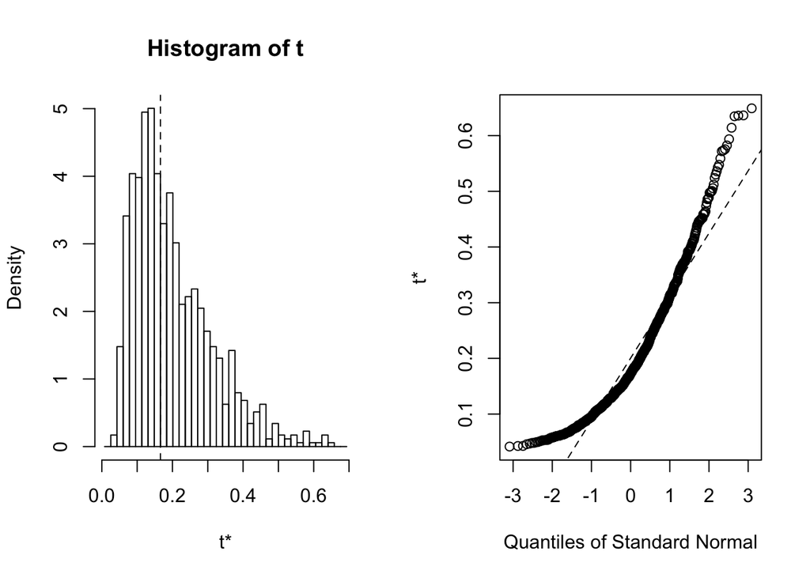

```r
plot(results)
```

```r
# get 95% confidence interval
boot.ci(results, type="bca")
```

```
## BOOTSTRAP CONFIDENCE INTERVAL CALCULATIONS
## Based on 1000 bootstrap replicates
##
## CALL :
## boot.ci(boot.out = results, type = "bca")
##
## Intervals :
## Level       BCa
## 95%   ( 0.0539,  0.4512 )
## Calculations and Intervals on Original Scale
```

logged:

```r
# Bootstrap 95% CI for R-Squared
library(boot)
# function to obtain R-Squared from the data
rsq <- function(formula, data, indices) {
  p <- data[indices,] # allows boot to select sample
  fit <- lm(formula, data=p)
  return(summary(fit)$r.square)
}
# bootstrapping with 1000 replications
results <- boot(data=d, statistic=rsq,
   R=1000, formula=log(HomeRange_km2) ~ log(Body_mass_female_mean))

# view results
results
```

```
##
## ORDINARY NONPARAMETRIC BOOTSTRAP
##
##
## Call:
## boot(data = d, statistic = rsq, R = 1000, formula = log(HomeRange_km2) ~
##     log(Body_mass_female_mean))
##
##
## Bootstrap Statistics :
##      original       bias    std. error
## t1* 0.5248282 -0.002113994  0.04887226
```

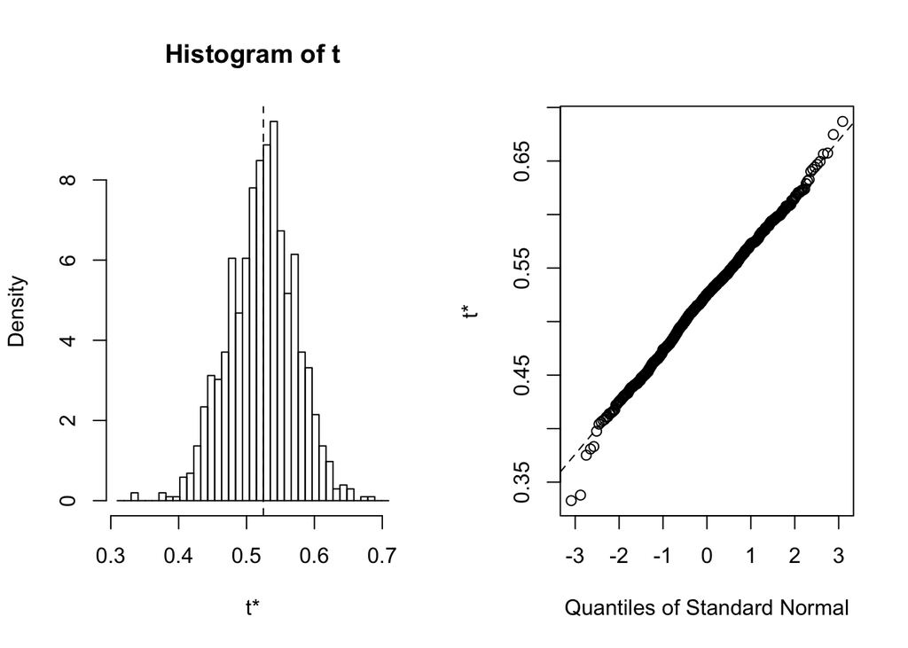

```r
plot(results)
```

```r
# get 95% confidence interval
boot.ci(results, type="bca")
```

```
## BOOTSTRAP CONFIDENCE INTERVAL CALCULATIONS
## Based on 1000 bootstrap replicates
##
## CALL :
## boot.ci(boot.out = results, type = "bca")
##
## Intervals :
## Level       BCa
## 95%   ( 0.4265,  0.6135 )
## Calculations and Intervals on Original Scale
```

How does the former compare to the SE estimated from your entire dataset using the formula for standard error implemented in lm()?

How does the latter compare to the 95% CI estimated from your entire dataset?

Write a FUNCTION that takes as its arguments a dataframe, “d”, a linear model, “m” (as a character string, e.g., “logHR~logBM”), a user-defined confidence interval level, “conf.level” (with default = 0.95), and a number of bootstrap replicates, “n” (with default = 1000). Your function should return a dataframe that includes: beta coefficient names; beta coefficients, standard errors, and upper and lower CI limits for the linear model based on your entire dataset; and mean beta coefficient estimates, SEs, and CI limits for those coefficients based on your bootstrap.

EXTRA EXTRA CREDIT

Graph each beta value from the linear model and its corresponding mean value, lower CI and upper CI from a bootstrap as a function of number of bootstraps from 10 to 200 by 10s. HINT: the beta value from the linear model will be the same for all bootstraps and the mean beta value may not differ that much!